# The Restricted Range Problem: Transformations

```r
suppressPackageStartupMessages(library(tidyverse))
```

In Regression I, the response was allowed to take on any real number. But what if the range is restricted?

## Problems

Here are some common examples.

1. Positive values: river flow.
   - Lower limit: 0
2. Percent/proportion data: proportion of income spent on housing in Vancouver.
   - Lower limit: 0
   - Upper limit: 1.
3. Binary data: success/failure data.
   - Only take values of 0 and 1.
4. Count data: number of male crabs nearby a nesting female
   - Only take count values (0, 1, 2, …)

Here is an example of the fat content of a cow’s milk, which was recorded over time. Data are from the paper [“Transform or Link?”](https://core.ac.uk/download/pdf/79036775.pdf). Let’s consider data as of week 10:

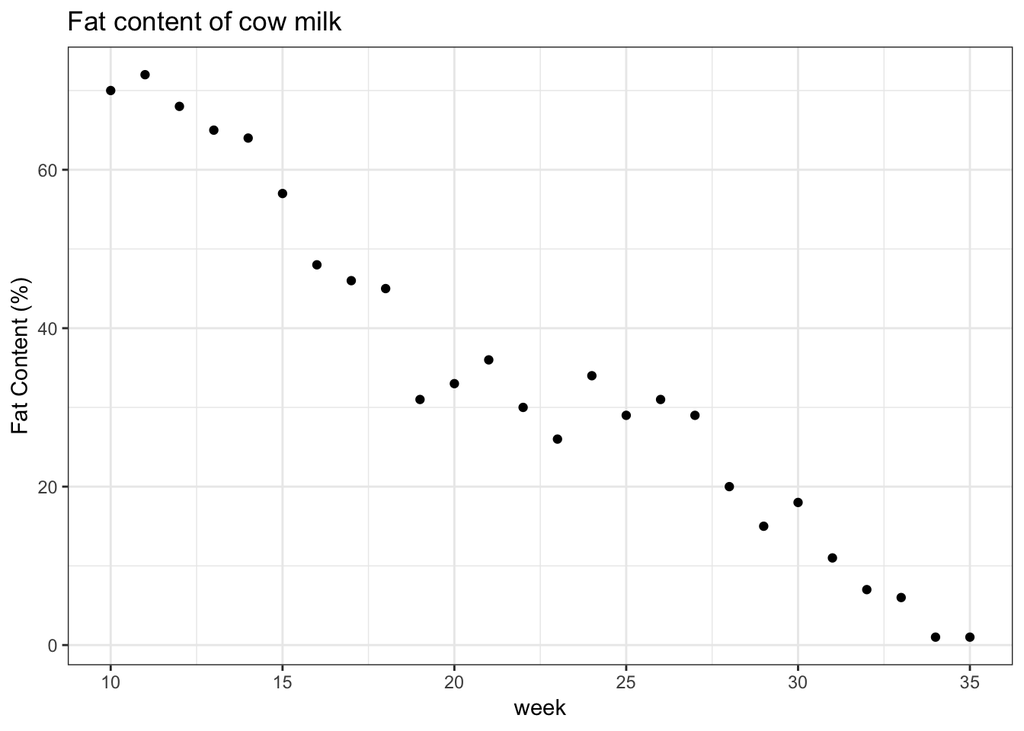

```r
cow <- suppressMessages(read_csv("../data/milk_fat.csv"))
(plot_cow <- cow %>%
    filter(week >= 10) %>%
    ggplot(aes(week, fat*100)) +
    geom_point() +
    theme_bw() +
    labs(y = "Fat Content (%)") +
    ggtitle("Fat content of cow milk"))
```

Let’s try fitting a linear regression model.

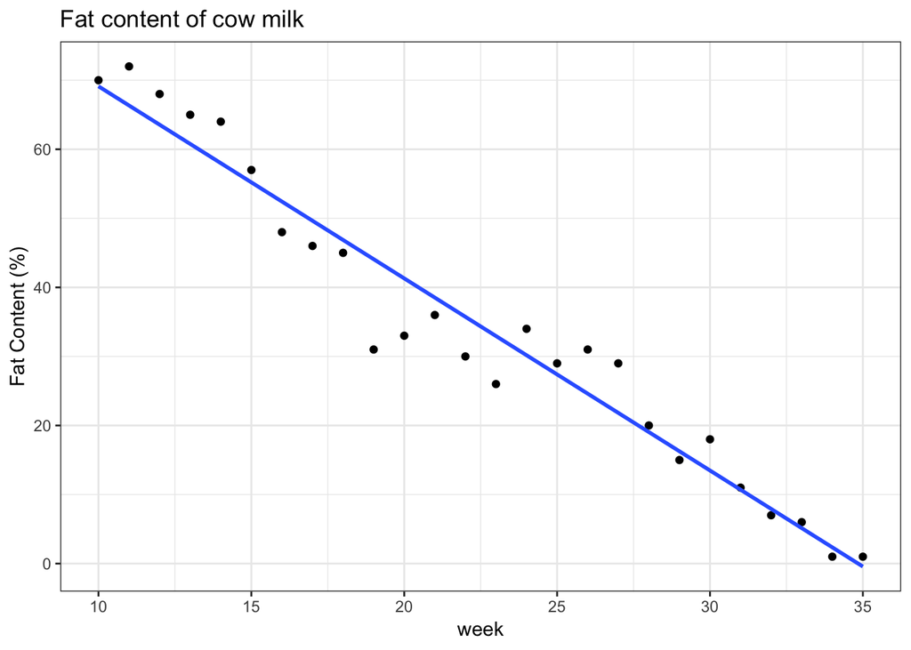

```r
plot_cow +
    geom_smooth(method = "lm", se = FALSE)
```

Notice the problem here – **the regression lines extend beyond the possible range of the response**. This is *mathematically incorrect*, since the expected value cannot extend outside of the range of Y. But what are the *practical* consequences of this?

In practice, when fitting a linear regression model when the range of the response is restricted, we lose hope for extrapolation, as we obtain logical fallacies if we do. In this example, a cow is expected to produce *negative* fat content after week 35!

Despite this, a linear regression model might still be useful in these settings. After all, the linear trend looks good for the range of the data.

## Solutions

How can we fit a regression curve to stay within the bounds of the data, while still retaining the interpretability that we have with a linear model function? Remember, non-parametric methods like random forests or loess will not give us interpretation. Here are some options:

1. Transform the data.
2. Transform the linear model function: link functions
3. Use a scientifically-backed parametric function.

### Solution 1: Transformations

One solution that *might* be possible is to transform the response so that its range is no longer restricted. The most typical example is for positive data, like river flow. If we log-transform the response, then the new response can be any real number. All we have to do is fit a linear regression model to this transformed data.

One downfall is that we lose interpretability, since we are estimating the mean of $\log(Y)$ (or some other transformation) given the predictors, not $Y$ itself! Transforming the model function by exponentiating will not fix this problem, either, since the exponential of an expectation is not the expectation of an exponential. Though, this is a mathematical technicality, and might still be a decent approximation in practice.

Also, transforming the response might not be fruitful. For example, consider a binary response. No transformation can spread the two values to be non-binary!

### Solution 2: Link Functions

Instead of transforming the data, why not transform the model function? For example, instead of taking the logarithm of the response, perhaps fit the model
$$E(Y|X=x) = \exp(\beta_0 + \beta x) = \alpha \exp(\beta x).$$
Or, in general,
$$g(E(Y|X=x)) = X^{\top} \beta$$
for some increasing function $g$ called the *link function*.

This has the added advantage that we do not need to be able to transform the response.

Two common examples of link functions:

- $\log$, for positive response values.
  - Parameter interpretation: an increase of one unit in the predictor is associated with an $\exp(\beta)$ times increase in the mean response, where $\beta$ is the slope parameter.
- $\text{logit}(x)=\log(x/(1-x))$, for binary response values.
  - Parameter interpretation: an increase of one unit in the predictor is associated with an $\exp(\beta)$ times increase in the odds of “success”, where $\beta$ is the slope parameter, and odds is the ratio of success to failure probabilities.

### Solution 3: Scientifically-backed functions

Sometimes there are theoretically derived formulas for the relationship between response and predictors, which have parameters that carry some meaning to them.